# Projet - Sélection de modèle en régression linéaire

2024-12-18

#### **Université de Bordeaux - M1 Master MAS - UE : Modèles de régression**

#### **Année 2024-2025**

**Nom : Aboukacem**  
**Prénom : Elias**

**Nom : Van Theo**  
**Prénom : Lahontaa**

**Nom : Pichard**  
**Prénom : Thomas**

### Visualisation de la répartition de la variable à expliquer selon le sexe

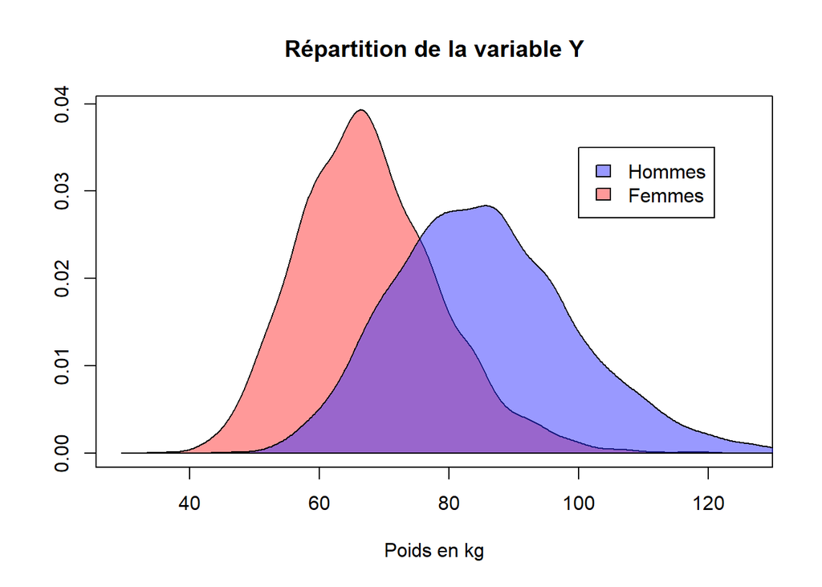

On remarque que le poids des hommes présente une variance plus importante que celui des femmes, ainsi qu’une moyenne supérieure également.

### Approche naive

Nous allons dans cette partie utiliser l’AIC naivement; on considère les donées masculines car plus d’individus pour aboutir à un premier modèle explicatif de la variable poids, puis nous le transposerons aux données féminines.

Nous allons prendre le jeu de donnés masculin, prendre une à une les variables et les supprimer, à chaque itération , si l’AIC obtenu par le modèle avec une variable en moins est inférieur à l’AIC du modèle complet, alors nous considérerons cette variable comme non pertinente pour expliquer le poids et elle sera supprimée après que la boucle soit terminée.

Nous avons au départ:

```
## Un AIC de :  14643.41
```

```
## Et un R² de:  0.990006
```

```r
library(dplyr)

# Define the function
remove_columns_based_on_AIC <- function(Y, dataframe, int_threshold) {

  # Initialize a vector to store the indices of columns to be removed
  columns_to_remove <- c()

  # Get the number of columns in the dataframe
  num_columns <- ncol(dataframe)

  # Ensure num_columns is a single numeric value
  if (!is.numeric(num_columns) || length(num_columns) != 1)
    { stop("num_columns should be a single numeric value") }

  # Loop through the columns from the last to the first
  for (i in seq(num_columns, 1, by = -1)) {
    # Ensure the column index is valid
    if (i > ncol(dataframe) || i < 1) {
      next
    }

    # Select the columns excluding the current column
    modified_data <- dataframe[, -i, drop = FALSE]

    # Fit the model
    model <- lm(Y[,1] ~ ., data = modified_data)

    # Calculate AIC
    aic_value <- round(AIC(model))

    # Check if AIC is smaller than the threshold
    if (aic_value < int_threshold) {
      columns_to_remove <- c(columns_to_remove, i)
    }
  }

  # Remove the stored columns from the dataframe
  if (length(columns_to_remove) > 0) {
    final_dataframe <- dataframe[, -columns_to_remove, drop = FALSE]
  } else {
    final_dataframe <- dataframe
  }

  return(final_dataframe)
}

aic_0m <- AIC(model <- lm(Y_m[,1] ~ ., data = X_m))
X_m <- remove_columns_based_on_AIC(Y_m, X_m, round(aic_0m))
aic_0m <- AIC(model <- lm(Y_m[,1] ~ ., data = X_m))
X_m <- remove_columns_based_on_AIC(Y_m, X_m, round(aic_0m))
```

L’étape suivante consiste avec le jeu de données réduits à 66 variables, de refaire une boucle en enlevant à chaque fois une variable et en faisant la différence entre l’AIC du modèle à 65 variables et l’AIC du modèle à 66 variables, cette différence est ensuite classée dans l’ordre décroissant dans un vecteur avec l’indice de la variable concernée, on décide de garder les 10 variables dont les différences sont les plus élevées. Puisque plus l’AIC est grand, moins le modèle est précis, et les grandes différences permettent de minimiser l’AIC pour 10 variables.

Après sélection de modèle, on obtient le modèle composé des 10 variables suivantes.

```r
select_model <- function(Y, X, nb) {
  # Initialize an empty vector to store (dif, index)
  index <- data.frame(dif = numeric(), column_index = integer())

  # Fit the initial model with all columns
  model <- lm(Y[,1] ~ ., data = X)

  # Calculate the initial AIC of the model
  initial_aic <- AIC(model)

  # Loop through each column in X
  for (i in 1:ncol(X)) {
    # Create a modified dataset by removing the i-th column
    modified_X <- X[, -i, drop = FALSE]

    # Fit the model with the modified dataset
    modified_model <- lm(Y[,1] ~ ., data = modified_X)

    # Calculate the AIC of the modified model
    modified_aic <- AIC(modified_model)

    # Calculate the difference in AIC
    dif <- modified_aic - initial_aic

    # Store the (dif, index) in the index data frame
    index <- rbind(index, data.frame(dif = dif, column_index = i))
  }

  # Sort the index data frame in descending order of dif values
  index <- index[order(-index$dif),]

  # Select the first `nb` columns from the sorted index
  top_columns <- index$column_index[1:nb]

  # Create a new dataset with only the selected columns
  new_X <- X[, top_columns, drop = FALSE]

  return(new_X)
}
X_m <- select_model(Y_m, X_m, 10)
model_m <- lm(Y_m[,1] ~ ., data = X_m)
cat("On obtient un AIC de : " ,AIC(model_m),"\n")
```

```
## On obtient un AIC de :  20655.3
```

```r
cat("Et un R² de: ", summary(model_m)$r.squared, "\n")
```

```
## Et un R² de:  0.954626
```

L’augmentation conséquente de l’AIC n’est pas satisfaisante. On rejette ce modèle.

### Selection du modèle final

Dans un premier temps, on applique la fonction “step()” dans les deux directions qui permet grâce à l’AIC et le BIC de sélectionner un modèle pour les données de chaque sexe.

```
## La fonction step pour les hommes avec l'AIC donne :
```

```
## 62 variables
```

```
## Les Variables sont :
##  buttockcircumference chestcircumference stature calfcircumference neckcircumference thighcircumference waistdepth bicepscircumferenceflexed lowerthighcircumference shouldercircumference anklecircumference thighclearance waistcircumference heelbreadth verticaltrunkcircumferenceusa buttockheight t…
```

```
## La fonction step pour les femmes avec l'AIC donne :
```

```
## 55 variables
```

```
## Les Variables sont :
##  buttockcircumference shouldercircumference verticaltrunkcircumferenceusa bicepscircumferenceflexed kneeheightsitting waistdepth calfcircumference chestcircumference lowerthighcircumference neckcircumference thighcircumference heelbreadth crotchheight crotchlengthomphalion waistcircumference hand…
```

```
## La fonction step pour les hommes avec le BIC donne :
```

```
## 38 variables
```

```
## Les Variables sont :
##  buttockcircumference chestcircumference stature calfcircumference neckcircumference thighcircumference waistdepth bicepscircumferenceflexed lowerthighcircumference shouldercircumference anklecircumference thighclearance waistcircumference heelbreadth verticaltrunkcircumferenceusa buttockheight t…
```

```
## La fonction step pour les femmes avec le BIC donne :
```

```
## 33 variables
```

```
## Les Variables sont :
##  buttockcircumference shouldercircumference verticaltrunkcircumferenceusa bicepscircumferenceflexed waistdepth calfcircumference chestcircumference stature lowerthighcircumference neckcircumference thighcircumference heelbreadth crotchheight crotchlengthomphalion waistcircumference handlength thi…
```

Nos modèles possèdent encore beaucoup de variables et ne sont pas du tout pratiques. On veut un modèle qui permet d’expliquer la variable d’intéret avec très peu de statistiques. On va donc limiter une selection forward a 10 variables.

```r
# Modèle de l'intercept (vide)
null_model <- lm(Y_m[,1] ~ 1, data = as.data.frame(X_m))

# Modèle complet
full_model <- lm(Y_m[,1] ~ ., data = as.data.frame(X_m))

# Forward Selection limité à 10 variables
step_model <- step(null_model,
                   scope = list(lower = null_model, upper = full_model),
                   direction = "forward",
                   steps = 10,
                   trace = FALSE)


# Variables sélectionnées
selected_vars_step <- names(coef(step_model))[-1]
cat("Variables sélectionnées pour le modèle à 10 variables chez les hommes:\n\n", selected_vars_step, "\n")
```

```
## Variables sélectionnées pour le modèle à 10 variables chez les hommes:
##
##  buttockcircumference chestcircumference stature calfcircumference neckcircumference thighcircumference waistdepth bicepscircumferenceflexed lowerthighcircumference shouldercircumference
```

Avec ce modèle, nous obtenons:

```
## Un AIC de :  15931.19
```

```
## Et un R² de:  0.9857375
```

Nous avons également obtenu par la fonction “step” contrainte à 5 pas, un modèle de 5 variables explicatives, qui expliquait 1% en moins la variable poids que le modèle à 10 variables. Cela peut être un modèle pertinent lorsque des mesures sur des milliers de personnes doivent être prise, mais dans notre cas, les mesures étant déjà disponibles, nous avons préféré gardé le modèle le plus précis et utilisé le maximum du nombre de variable permis.

Nous appliquerons également ce modèle aux données féminines afin de comparer les ACP.

### ACP normée

#### Matrices de correlation

Pour les hommes:

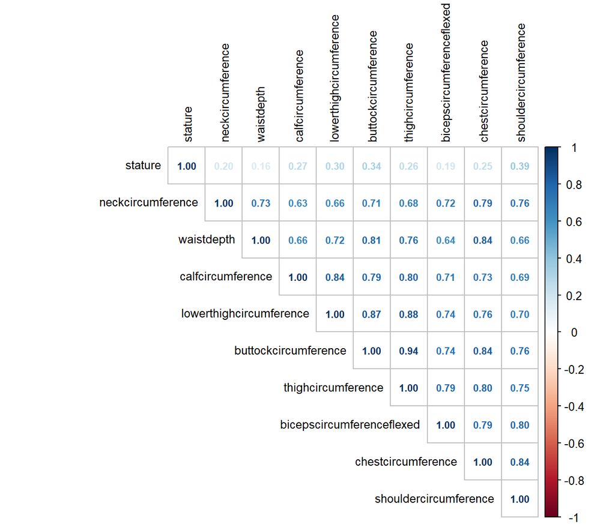

```r
# Créer la matrice de corrélation
cor_matrix <- cor(data_scaled)

# Visualiser la corrélation avec des ajustements pour la lisibilité
corrplot(cor_matrix,
         method = "number",          # Afficher les nombres
         type = "upper",             # Afficher uniquement la partie supérieure
         order = "hclust",           # Regrouper les variables par clustering hiérarchique
         number.cex = 0.7,           # Réduire la taille des nombres
         tl.cex = 0.8,               # Taille des étiquettes des axes
         tl.col = "black",           # Couleur des étiquettes
         cl.cex = 0.8)               # Taille de la légende des couleurs
```

- Les variables **buttockcircumference**, **thighcircumference**, et **lowerthighcircumference** présentent de fortes corrélations entre elles (r ≈ 0.8-0.9).
- La variable **stature** est faiblement corrélée avec les autres variables (r ≈ 0.2-0.3), indiquant que la taille n’a pas une relation directe avec ces mesures.
- Les corrélations entre **chestcircumference**, **shouldercircumference**, et **neckcircumference** restent modérées à fortes (r ≈ 0.7-0.8).

Pour les femmes:

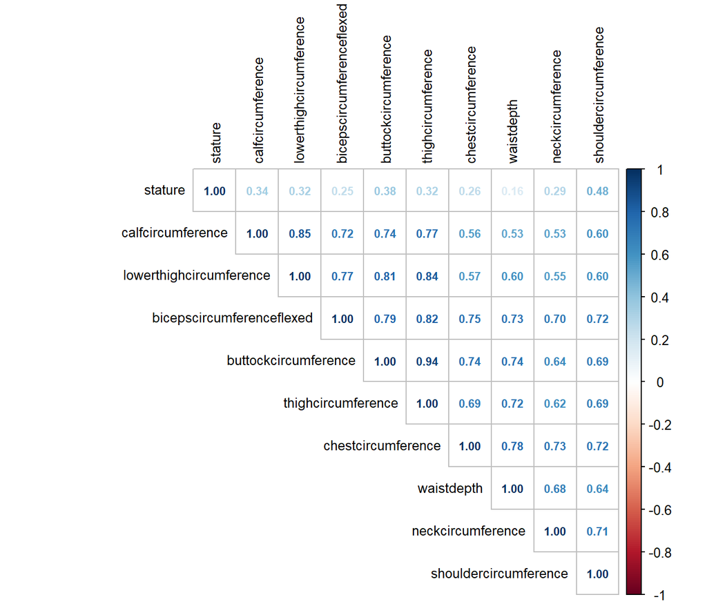

```r
# Créer la matrice de corrélation
cor_matrix_f <- cor(data_scaled_f)

# Visualiser la corrélation avec des ajustements pour la lisibilité
corrplot(cor_matrix_f,
         method = "number",          # Afficher les nombres
         type = "upper",             # Afficher uniquement la partie supérieure
         order = "hclust",           # Regrouper les variables par clustering hiérarchique
         number.cex = 0.7,           # Réduire la taille des nombres
         tl.cex = 0.8,               # Taille des étiquettes des axes
         tl.col = "black",           # Couleur des étiquettes
         cl.cex = 0.8)               # Taille de la légende des couleurs
```

La relation entre stature et les autres variables, plus prononcée chez les femmes pourrait s’expliquer par une moyenne de taille et une variance toute deux inférieure chez les femmes comparée aux hommes.

#### Valeurs propres et Variance expliquée

Pour les hommes:

```
##        eigenvalue percentage of variance cumulative percentage of variance
## comp 1 5.63695983             70.4619978                          70.46200
## comp 2 0.94203207             11.7754009                          82.23740
## comp 3 0.44565887              5.5707359                          87.80813
## comp 4 0.37475045              4.6843807                          92.49252
## comp 5 0.25480106              3.1850132                          95.67753
## comp 6 0.18355645              2.2944557                          97.97198
## comp 7 0.11895345              1.4869181                          99.45890
## comp 8 0.04328782              0.5410977                         100.00000
```

- **Dim1 (70.5%)** : Explique la majorité de la variance. Cette composante principale est dominée par des variables telles que **buttockcircumference**, **thighcircumference**, et **lowerthighcircumference**.
- **Dim2 (11.8%)** : Représente une faible partie de la variance. Elle pourrait être associée à des variables moins corrélées comme **stature**.

> **Cumul** : Les deux premières dimensions expliquent **82.2%** de la variance totale.

Pour les femmes:

```
##        eigenvalue percentage of variance cumulative percentage of variance
## comp 1 5.40700909             67.5876136                          67.58761
## comp 2 0.93985730             11.7482162                          79.33583
## comp 3 0.61506113              7.6882641                          87.02409
## comp 4 0.36026628              4.5033285                          91.52742
## comp 5 0.23146578              2.8933223                          94.42074
## comp 6 0.20323862              2.5404827                          96.96123
## comp 7 0.19222577              2.4028222                          99.36405
## comp 8 0.05087603              0.6359504                         100.00000
```

- **Dim1 (67.6%)** : Explique une part légèrement moindre de la variance, mais domine toujours avec des variables similaires : **buttockcircumference**, **thighcircumference**, et **lowerthighcircumference**.
- **Dim2 (11.7%)** : Similaire au cas des hommes, elle reste faible et semble reliée à des variables distinctes comme **waistdepth** et **stature**.

> **Cumul** : Les deux premières dimensions expliquent **79.3%** de la variance totale chez les femmes, légèrement inférieur à celui des hommes.

#### Graphique du coude

pour les hommes:

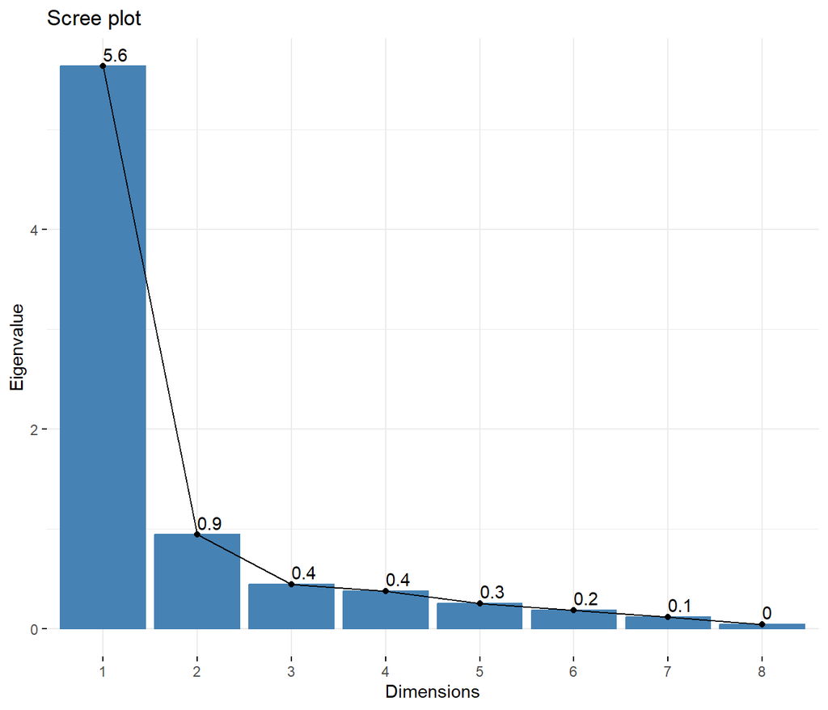

```r
fviz_eig(pca.deca.R, choice = "eigenvalue", addlabels=TRUE)
```

- Le graphique montre une **diminution rapide des valeurs propres** après la première dimension. La **Dim1** domine avec une valeur de **5.6**, suivie par **Dim2 (0.9)**.
- À partir de **Dim3**, les valeurs deviennent négligeables, indiquant que seules les deux premières dimensions sont pertinentes.

Pour les femmes:

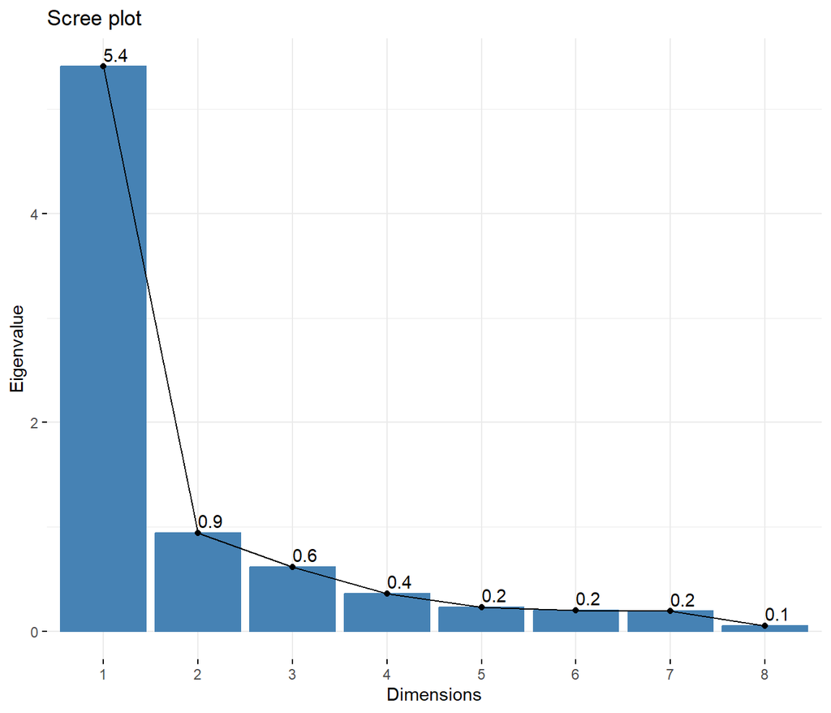

```r
fviz_eig(pca.deca.Rf, choice = "eigenvalue", addlabels=TRUE)
```

Une tendance similaire est observée : **Dim1 (5.4)** domine, suivie par **Dim2 (0.9)**. La chute des valeurs propres est moins abrupte pour les **Dim3** et **Dim4**, indiquant une variance légèrement plus répartie.

#### Cercle des corrélations

pour les hommes:

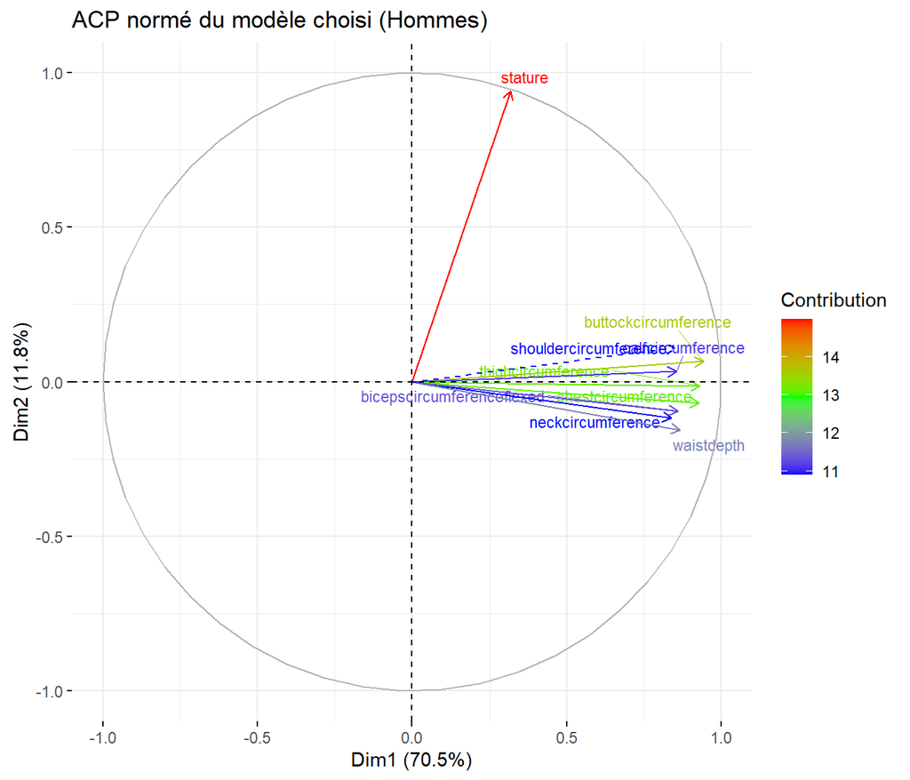

```r
fviz_pca_var(pca.deca.R,
             axes = c(1, 2),
             col.var = "contrib",               # Couleur en fonction de la contribution
             gradient.cols = c("blue", "green", "red"),  # Palette de couleurs
             legend.title = "Contribution",     # Titre de la légende
             repel = TRUE,                      # Évite le chevauchement des étiquettes
             arrow.size = 1.2,                  # Taille des flèches
             labelsize = 3,                     # Taille des étiquettes
             title = "ACP normé du modèle choisi (Hommes)")
```

**Dim1 (70.5%)** :

- **Caractéristique dominante** : Cette dimension est fortement liée aux **circonférences corporelles** :
  - **buttockcircumference**, **thighcircumference**, **lowerthighcircumference** et **calfcircumference**.
- **Interprétation** : Elle représente principalement la **morphologie globale** ou la **masse corporelle totale**, particulièrement dans les membres inférieurs et la région fessière.
- **Lien avec le poids** : Cette dimension est directement corrélée à des caractéristiques massives, ce qui en fait un bon indicateur du poids corporel.

**Dim2 (11.8%)** :

- **Caractéristique dominante** : La dimension 2 est liée principalement à la **stature**.
- **Interprétation** : Elle représente la **taille longitudinale** (hauteur) du corps, indépendamment des circonférences.
- **Lien avec le poids** : La stature, bien qu’importante, est moins corrélée aux variables de volume, expliquant ainsi sa faible contribution relative.

Pour les femmes:

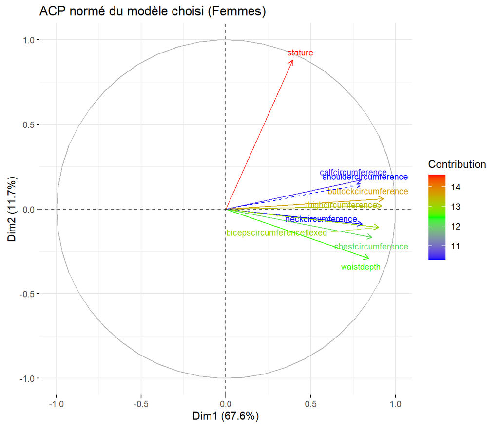

```r
fviz_pca_var(pca.deca.Rf,
             axes = c(1, 2),
             col.var = "contrib",               # Couleur en fonction de la contribution
             gradient.cols = c("blue", "green", "red"),  # Palette de couleurs
             legend.title = "Contribution",     # Titre de la légende
             repel = TRUE,                      # Évite le chevauchement des étiquettes
             arrow.size = 1.2,                  # Taille des flèches
             labelsize = 3,                     # Taille des étiquettes
             title = "ACP normé du modèle choisi (Femmes)")
```

**Dim1 (67.6%)** :

- **Caractéristique dominante** : Tout comme chez les hommes, cette dimension est dominée par les **circonférences corporelles**, notamment :
  - **buttockcircumference**, **thighcircumference**, **lowerthighcircumference**, et **calfcircumference**.
- **Interprétation** : Elle représente la **morphologie générale** du corps féminin, avec un focus particulier sur les membres inférieurs et les régions volumineuses.
- **Lien avec le poids** : Les mêmes caractéristiques sont directement liées au poids corporel.

**Remarques**

#### Conclusion sur les Dimensions

[output not shown]

### Ouverture

On peut aussi essayer de distinguer les hommes et les femmes, On prend ici un modèle plus petit afin de pouvoir avoir plus d’explicabilitée biologique :

```r
# Ajouter la variable binaire "gender"
donnees_m$gender <- 0  # Male = 0
donnees_f$gender <- 1  # Female = 1

# Fusionner les deux jeux de données
combined_data <- rbind(donnees_m, donnees_f)

# Diviser les données en variables explicatives (X) et réponse (Y)
Y <- combined_data$gender
X <- combined_data[, -ncol(combined_data)]  # Exclure la colonne "gender"

# Modèle de base (vide)
null_model <- lm(Y ~ 1, data = as.data.frame(X))

# Modèle complet
full_model <- lm(Y ~ ., data = as.data.frame(X))

# Forward Selection limité à 5 variables
step_model <- step(null_model,
                   scope = list(lower = null_model, upper = full_model),
                   direction = "forward",
                   steps = 3,
                   trace = FALSE)


# Variables sélectionnées
selected_vars_step <- names(coef(step_model))[-1]
cat("Variables sélectionnées pour le modèle à 3 variables :\n", selected_vars_step, "\n")
```

```
## Variables sélectionnées pour le modèle à 3 variables :
##  neckcircumference hipbreadthsitting chestheight
```

```r
# Résumé du modèle à 3 variables
cat("\nRésumé du modèle sélectionné :\n")
```

```
##
## Résumé du modèle sélectionné :
```

```r
summary(step_model)
```

```
##
## Call:
## lm(formula = Y ~ neckcircumference + hipbreadthsitting + chestheight,
##     data = as.data.frame(X))
##
## Residuals:
##      Min       1Q   Median       3Q      Max
## -0.71530 -0.13449 -0.00924  0.13228  0.89169
##
## Coefficients:
##                     Estimate Std. Error t value Pr(>|t|)
## (Intercept)        3.347e+00  4.988e-02   67.11   <2e-16 ***
## neckcircumference -7.713e-03  8.340e-05  -92.48   <2e-16 ***
## hipbreadthsitting  5.148e-03  7.828e-05   65.76   <2e-16 ***
## chestheight       -1.685e-03  4.145e-05  -40.66   <2e-16 ***
## ---
## Signif. codes:  0 '***' 0.001 '**' 0.01 '*' 0.05 '.' 0.1 ' ' 1
##
## Residual standard error: 0.1958 on 6064 degrees of freedom
## Multiple R-squared:  0.8259, Adjusted R-squared:  0.8258
## F-statistic:  9591 on 3 and 6064 DF,  p-value: < 2.2e-16
```

Notre modèle avec seulement trois variables permet d'expliquer 80% de nos valeurs, c'est un très bon résultat en utilisant seulement 3 variables explicatives.

Essayons un modèle supplémentaire:

```
## Variables sélectionnées pour le modèle à n variables (Male):
##  neckcircumference hipbreadthsitting chestheight tenthribheight biacromialbreadth crotchlengthomphalion lateralmalleolusheight lateralfemoralepicondyleheight waistheightomphalion buttockdepth trochanterionheight chestdepth waistbreadth bicristalbreadth waistbacklength bicepscircumferenceflexed ea…
```

```
##
## Résumé du modèle sélectionné :
```

```
##
## Call:
## lm(formula = Y ~ neckcircumference + hipbreadthsitting + chestheight +
##     tenthribheight + biacromialbreadth + crotchlengthomphalion +
##     lateralmalleolusheight + lateralfemoralepicondyleheight +
##     waistheightomphalion + buttockdepth + trochanterionheight +
##     chestdepth + waistbreadth + bicristalbreadth + waistbacklength +
##     bicepscircumferenceflexed + earbreadth + wristheight + chestcircumference +
##     chestbreadth + bimalleolarbreadth + span + sleeveoutseam +
##     buttockcircumference + poplitealheight + headcircumference +
##     headlength + headbreadth + radialestylionlength + stature +
##     handcircumference + forearmforearmbreadth + mentonsellionlength +
##     hipbreadth + tibialheight + kneeheightmidpatella + crotchlengthposterioromphalion +
##     earprotrusion + anklecircumference + heelanklecircumference +
##     bitragionchinarc + handlength + axillaheight + thighcircumference +
##     weightkg + neckcircumferencebase + sleevelengthspinewrist +
##     footlength + shoulderlength + shouldercircumference + acromionradialelength +
##     heelbreadth + waistdepth + interscyeii + interscyei + verticaltrunkcircumferenceusa +
##     buttockheight, data = as.data.frame(X))
##
## Residuals:
##      Min       1Q   Median       3Q      Max
## -0.54427 -0.07699 -0.00002  0.07728  0.44938
##
## Coefficients:
##                                  Estimate Std. Error t value Pr(>|t|)
## (Intercept)                     2.639e+00  1.448e-01  18.231  < 2e-16 ***
## neckcircumference              -3.575e-03  1.975e-04 -18.106  < 2e-16 ***
## hipbreadthsitting               1.296e-03  1.680e-04   7.717 1.38e-14 ***
## chestheight                    -1.732e-03  9.697e-05 -17.856  < 2e-16 ***
## tenthribheight                  2.453e-03  1.289e-04  19.027  < 2e-16 ***
## biacromialbreadth              -1.511e-03  1.891e-04  -7.994 1.56e-15 ***
## crotchlengthomphalion           1.254e-03  8.207e-05  15.282  < 2e-16 ***
## lateralmalleolusheight         -3.472e-03  3.411e-04 -10.177  < 2e-16 ***
## lateralfemoralepicondyleheight  2.111e-03  2.158e-04   9.780  < 2e-16 ***
## waistheightomphalion           -2.304e-03  1.607e-04 -14.333  < 2e-16 ***
## buttockdepth                   -2.994e-03  1.887e-04 -15.865  < 2e-16 ***
## trochanterionheight             7.609e-04  1.316e-04   5.781 7.81e-09 ***
## chestdepth                      4.222e-03  1.779e-04  23.735  < 2e-16 ***
## waistbreadth                   -1.950e-03  1.357e-04 -14.361  < 2e-16 ***
```

[output cut: 35 more lines]

```
## shoulderlength                  9.241e-04  2.528e-04   3.655 0.000259 ***
## shouldercircumference          -4.165e-04  8.963e-05  -4.647 3.45e-06 ***
## acromionradialelength           1.120e-03  2.843e-04   3.941 8.21e-05 ***
## heelbreadth                     1.414e-03  4.323e-04   3.271 0.001079 **
## waistdepth                     -4.586e-04  1.307e-04  -3.509 0.000453 ***
## interscyeii                     1.410e-03  2.080e-04   6.778 1.33e-11 ***
## interscyei                     -1.043e-03  1.754e-04  -5.949 2.85e-09 ***
## verticaltrunkcircumferenceusa   2.053e-04  6.492e-05   3.162 0.001573 **
## buttockheight                   3.762e-04  1.310e-04   2.871 0.004105 **
## ---
## Signif. codes:  0 '***' 0.001 '**' 0.01 '*' 0.05 '.' 0.1 ' ' 1
##
## Residual standard error: 0.1175 on 6010 degrees of freedom
## Multiple R-squared:  0.9379, Adjusted R-squared:  0.9373
## F-statistic:  1593 on 57 and 6010 DF,  p-value: < 2.2e-16
```

Ce modèle est beaucoup plus compliqué et semble ne représenter aucun interet pratique.

Analysons donc le call lm de notre plus petit modèle. Notre petit modèle explique 80% des valeurs.

neckcircumference : Cette variable a un effet négatif très significatif sur la variable sexe. Cela suggère que plus la circonférence du cou est grande, plus il est probable que l’individu soit un homme (valeur proche de 0).

hipbreadthsitting : Cette variable a un effet positif significatif sur le sexe, indiquant que plus la largeur des hanches est grande en position assise, plus il est probable que l’individu soit une femme.

chestheight : L’augmentation de la hauteur du torse semble être associée à une plus grande probabilité d’être un homme.